# Stats 506 Problem Set 3

Author

Honghao Wang

GitHub Repo: https://github.com/whonghao-code/stats506/tree/main

## **Problem 1**

(a) The resulting merged data.frame contains 4,582 observations and 119 variables.

```r
library(haven)
library(dplyr)
aux_data <- read_xpt("AUX_I.XPT")
demo_data <- read_xpt("DEMO_I.XPT")

merged_data <- inner_join(demo_data, aux_data, by = "SEQN")

cat("Dimensions of the merged data.frame:\n")
```

```
Dimensions of the merged data.frame:
```

```r
print(dim(merged_data))
```

```
[1] 4582  119
```

(b) I cleaned the required demographic variables to prepare them for analysis.

For annual household income, the issue is that the original variable included categories 12 (Under $20,000) and 13 ($20,000 and Over) which broke the ordinal numeric sequence of the other income brackets. So I replaced categories 12, 13, 77 (Refused), and 99 (Don’t know) with NA.

```r
cleaned_data <- merged_data %>%
  mutate(
    # Gender: 1 = Male, 2 = Female
    Gender = factor(RIAGENDR, levels = c(1, 2), labels = c("Male", "Female")),

    # Citizenship status: 1 = Citizen, 2 = Not a citizen.
    # Values 7 and 9 are set to NA.
    Citizenship = ifelse(DMDCITZN %in% c(7, 9), NA, DMDCITZN),
    Citizenship = factor(Citizenship, levels = c(1, 2), labels = c("Citizen", "Not Citizen")),

    # Number of children 5 years or younger:
    # Values 77 and 99 are set to NA.
    Children_under_5 = ifelse(DMDHHSZA %in% c(77, 99), NA, DMDHHSZA),

    # Annual household income
    # Issue: Categories 12 and 13 are broad overlapping groups that break the ordinal
    # Values 12, 13, 77 and 99 are set to NA.
    Income_Code = ifelse(INDHHIN2 %in% c(12, 13, 77, 99), NA, INDHHIN2),
    Income = as.numeric(Income_Code)
  )

summary(cleaned_data %>% select(Gender, Citizenship, Children_under_5, Income))
```

```
    Gender          Citizenship   Children_under_5     Income
 Male  :2176   Citizen    :3684   Min.   :0.0000   Min.   : 1.000
 Female:2406   Not Citizen: 884   1st Qu.:0.0000   1st Qu.: 6.000
               NA's       :  14   Median :0.0000   Median : 8.000
                                  Mean   :0.3418   Mean   : 8.764
                                  3rd Qu.:0.0000   3rd Qu.:14.000
                                  Max.   :3.0000   Max.   :15.000
                                                   NA's   :495
```

(c) I fitted four Poisson regression models to predict the right and left ear tympanometric widths. The IRRs, the sample size, pseudo-$R^2$, and AIC values, are presented in the formatted kable table below.

```r
library(tidyr)
library(broom)
library(knitr)
# Model 1R: Right ear ~ gender
m1R <- glm(AUXTWIDR ~ Gender, family = poisson, data = cleaned_data)

# Model 2R: Right ear ~ gender + citizenship + children + income
m2R <- glm(AUXTWIDR ~ Gender + Citizenship + Children_under_5 + Income, family = poisson, data = cleaned_data)

# Model 1L: Left ear ~ gender
m1L <- glm(AUXTWIDL ~ Gender, family = poisson, data = cleaned_data)

# Model 2L: Left ear ~ gender + citizenship + children + income
m2L <- glm(AUXTWIDL ~ Gender + Citizenship + Children_under_5 + Income, family = poisson, data = cleaned_data)

# Calculate Pseudo R-squared
calc_pseudo_r2 <- function(model) {
  round(1 - (model$deviance / model$null.deviance), 4)
}
pseudo_R2 <- c(calc_pseudo_r2(m1R), calc_pseudo_r2(m2R), calc_pseudo_r2(m1L), calc_pseudo_r2(m2L))

exp_coefs <- list(exp(coef(m1R)), exp(coef(m2R)), exp(coef(m1L)), exp(coef(m2L)))

# Extract coefficients for each model and exponentiate to get IRRs
t1 <- tidy(m1R, exponentiate = TRUE) %>% select(term, estimate) %>% rename(`Model 1R (Right)` = estimate)
t2 <- tidy(m2R, exponentiate = TRUE) %>% select(term, estimate) %>% rename(`Model 2R (Right)` = estimate)
t3 <- tidy(m1L, exponentiate = TRUE) %>% select(term, estimate) %>% rename(`Model 1L (Left)` = estimate)
t4 <- tidy(m2L, exponentiate = TRUE) %>% select(term, estimate) %>% rename(`Model 2L (Left)` = estimate)

coef_table <- t1 %>%
  full_join(t2, by = "term") %>%
  full_join(t3, by = "term") %>%
  full_join(t4, by = "term") %>%
  mutate(across(-term, ~ sprintf("%.3f", .x))) %>%
  mutate(across(-term, ~ ifelse(.x == "NA", "", .x)))

format_aic <- function(model) {
  formatC(AIC(model), format = "f", digits = 1, big.mark = ",")
}

stats_table <- data.frame(
  term = c("---", "Sample Size (n)", "Pseudo R-squared", "AIC"),
  `Model 1R (Right)` = c("---", as.character(nobs(m1R)), sprintf("%.4f", pseudo_R2[1]), format_aic(m1R)),
  `Model 2R (Right)` = c("---", as.character(nobs(m2R)), sprintf("%.4f", pseudo_R2[2]), format_aic(m2R)),
  `Model 1L (Left)`  = c("---", as.character(nobs(m1L)), sprintf("%.4f", pseudo_R2[3]), format_aic(m1L)),
  `Model 2L (Left)`  = c("---", as.character(nobs(m2L)), sprintf("%.4f", pseudo_R2[4]), format_aic(m2L)),
  check.names = FALSE
)

final_table <- bind_rows(coef_table, stats_table)

kable(final_table,
      digits = 3,
      caption = "Poisson Regression Models",
      align = "lcccc")
```

Poisson Regression Models

| term | Model 1R (Right) | Model 2R (Right) | Model 1L (Left) | Model 2L (Left) |
| --- | --- | --- | --- | --- |
| (Intercept) | 84.317 | 88.183 | 84.758 | 87.950 |
| GenderFemale | 1.009 | 1.015 | 1.013 | 1.019 |
| CitizenshipNot Citizen |  | 1.046 |  | 1.022 |
| Children_under_5 |  | 0.994 |  | 0.983 |
| Income |  | 0.993 |  | 0.995 |
| — | — | — | — | — |
| Sample Size (n) | 4149 | 3705 | 4103 | 3665 |
| Pseudo R-squared | 0.0001 | 0.0068 | 0.0002 | 0.0036 |
| AIC | 96,618.5 | 84,850.5 | 98,685.1 | 86,602.0 |

(d)

1. Test for Incidence Risk Ratio (IRR) Difference

**Test Results:** For the female gender coefficient, the estimated IRR is 1.02. The 95% confidence interval is [1.01, 1.03], and the p-value is 0.000000224.

**Interpretation:** The p-value is much less than 0.05, so we reject the null hypothesis. There is strong evidence of a difference in the incidence risk ratio between men and women. Holding other variables constant, the rate for females is expected to be 1.02 times higher than for males.

2. Test for Predicted Value Difference

**Test Results:** The emmeans contrast test compares the predicted values for males and females. The estimated ratio (Male / Female) is 0.982. The p-value is < 0.0001.

**Interpretation:** Because the p-value is less than 0.05, we reject the null hypothesis. There is a statistically significant difference in the predicted tympanometric width of the left ear between men and women. The predicted value for males is slightly lower than for females.

```r
library(emmeans)
m2L_irr_results <- tidy(m2L, exponentiate = TRUE, conf.int = TRUE)
irr_test <- m2L_irr_results[m2L_irr_results$term == "GenderFemale", ]

cat("Incidence Risk Ratio (IRR) Difference")
```

```
Incidence Risk Ratio (IRR) Difference
```

```r
print(irr_test[, c("term", "estimate", "p.value", "conf.low", "conf.high")])
```

```
# A tibble: 1 × 5
  term         estimate     p.value conf.low conf.high
  <chr>           <dbl>       <dbl>    <dbl>     <dbl>
1 GenderFemale     1.02 0.000000224     1.01      1.03
```

```r
pred_values <- emmeans(m2L, ~ Gender, type = "response")
pred_test <- pairs(pred_values)
print(pred_test)
```

```
 contrast      ratio      SE  df null z.ratio p.value
 Male / Female 0.982 0.00353 Inf    1  -5.178 <0.0001

Results are averaged over the levels of: Citizenship
Tests are performed on the log scale
```

## **Problem 2 - Sakila**

(a) Based on the data extracted from the Sakila database, Store 1 has a total of 326 customers, with approximately 97.55% of them being active. Store 2 has 273 customers, with approximately 97.44% being active.

```r
library(microbenchmark)
library(RSQLite)
con <- dbConnect(SQLite(), "sakila_master.db")

# Method 1: Extract data via simple SQL and process using R operations
get_customers_r <- function() {
  customer_df <- dbGetQuery(con, "SELECT store_id, active FROM customer")

  result <- customer_df %>%
    group_by(store_id) %>%
    summarize(
      total_customers = n(),
      pct_active = mean(as.numeric(active)) * 100
    ) %>%
    ungroup()

  return(result)
}

# Method 2: Process entirely using a single SQL query
get_customers_sql <- function() {

  query <- "
    SELECT
      store_id,
      COUNT(customer_id) AS total_customers,
      AVG(active) * 100 AS pct_active
    FROM customer
    GROUP BY store_id
  "
  result <- dbGetQuery(con, query)
  return(result)
}

# Verify that both methods yield the same results
cat("--- Result from Method 1 (R operations) ---\n")
```

```
--- Result from Method 1 (R operations) ---
```

```r
print(get_customers_r())
```

```
# A tibble: 2 × 3
  store_id total_customers pct_active
     <int>           <int>      <dbl>
1        1             326       97.5
2        2             273       97.4
```

```r
cat("\n--- Result from Method 2 (Single SQL query) ---\n")
```

```
--- Result from Method 2 (Single SQL query) ---
```

```r
print(get_customers_sql())
```

```
  store_id total_customers pct_active
1        1             326   97.54601
2        2             273   97.43590
```

```r
# Compare the performance using microbenchmark
cat("\n--- Running microbenchmark ---\n")
```

```
--- Running microbenchmark ---
```

```r
mb_results_2a <- microbenchmark(
  R_Method = get_customers_r(),
  SQL_Method = get_customers_sql(),
  times = 100
)
print(mb_results_2a)
```

```
Unit: microseconds
       expr    min      lq     mean  median     uq    max neval
   R_Method 1753.5 1878.55 2070.155 1953.25 2042.3 5149.2   100
 SQL_Method  244.4  274.30  323.114  304.15  319.7 1582.4   100
```

(b) The result is that the staff members are Mike Hillyer (located in Canada) and Jon Stephens (located in Australia).

```r
# Method 1: Extract individual tables via simple SQL and join using R
get_staff_r <- function() {

  staff_df <- dbGetQuery(con, "SELECT first_name, last_name, address_id FROM staff")
  address_df <- dbGetQuery(con, "SELECT address_id, city_id FROM address")
  city_df <- dbGetQuery(con, "SELECT city_id, country_id FROM city")
  country_df <- dbGetQuery(con, "SELECT country_id, country FROM country")

  # Join the tables in R
  result <- staff_df %>%
    inner_join(address_df, by = "address_id") %>%
    inner_join(city_df, by = "city_id") %>%
    inner_join(country_df, by = "country_id") %>%
    select(first_name, last_name, country)

  return(result)
}

# Method 2: Process entirely using a single SQL query
get_staff_sql <- function() {
  query <- "
    SELECT
      s.first_name,
      s.last_name,
      c.country
    FROM staff s
    INNER JOIN address a ON s.address_id = a.address_id
    INNER JOIN city ci ON a.city_id = ci.city_id
    INNER JOIN country c ON ci.country_id = c.country_id
  "
  result <- dbGetQuery(con, query)
  return(result)
}

# Verify that both methods yield the same results
cat("--- Result from Method 1 (R operations) ---\n")
```

```
--- Result from Method 1 (R operations) ---
```

```r
print(get_staff_r())
```

```
  first_name last_name   country
1       Mike   Hillyer    Canada
2        Jon  Stephens Australia
```

```r
cat("\n--- Result from Method 2 (Single SQL query) ---\n")
```

```
--- Result from Method 2 (Single SQL query) ---
```

```r
print(get_staff_sql())
```

```
  first_name last_name   country
1       Mike   Hillyer    Canada
2        Jon  Stephens Australia
```

```r
# Compare the performance using microbenchmark
cat("\n--- Running microbenchmark ---\n")
```

```
--- Running microbenchmark ---
```

```r
mb_results_2b <- microbenchmark(
  R_Method = get_staff_r(),
  SQL_Method = get_staff_sql(),
  times = 100
)
print(mb_results_2b)
```

```
Unit: microseconds
       expr    min      lq     mean  median      uq    max neval
   R_Method 3415.0 3520.75 3887.227 3667.15 3876.35 8367.1   100
 SQL_Method  169.8  198.85  243.266  234.25  245.35 1497.7   100
```

(c) The films which were rented for the highest dollar value are SCORPION APOLLO, FLINTSTONES HAPPINESS, SHOW LORD, TRAP GUYS, TIES HUNGER, VIRTUAL SPOILERS, STING PERSONAL, MINE TITANS, and MIDSUMMER GROUNDHOG.

```r
# Method 1: Extract individual tables via SQL and process using R
get_highest_rental_r <- function() {
  film_df <- dbGetQuery(con, "SELECT film_id, title FROM film")
  inventory_df <- dbGetQuery(con, "SELECT inventory_id, film_id FROM inventory")
  rental_df <- dbGetQuery(con, "SELECT rental_id, inventory_id FROM rental")
  payment_df <- dbGetQuery(con, "SELECT rental_id, amount FROM payment")

  merged <- payment_df %>%
    inner_join(rental_df, by = "rental_id") %>%
    inner_join(inventory_df, by = "inventory_id") %>%
    inner_join(film_df, by = "film_id")

  # Find the maximum payment amount
  max_amount <- max(merged$amount, na.rm = TRUE)

  # Filter for the film that match this maximum amount
  result <- merged %>%
    filter(amount == max_amount) %>%
    select(title) %>%
    distinct()

  return(result)
}

# Method 2: Process using a single SQL query
get_highest_rental_sql <- function() {
  query <- "
    SELECT DISTINCT f.title
    FROM film f
    INNER JOIN inventory i ON f.film_id = i.film_id
    INNER JOIN rental r ON i.inventory_id = r.inventory_id
    INNER JOIN payment p ON r.rental_id = p.rental_id
    WHERE p.amount = (SELECT MAX(amount) FROM payment)
  "
  result <- dbGetQuery(con, query)
  return(result)
}

# Verify that both methods yield the same results
cat("--- Result from Method 1 (R operations) ---\n")
```

```
--- Result from Method 1 (R operations) ---
```

```r
print(get_highest_rental_r())
```

```
                  title
1       SCORPION APOLLO
2 FLINTSTONES HAPPINESS
3             SHOW LORD
4             TRAP GUYS
5           TIES HUNGER
6      VIRTUAL SPOILERS
7        STING PERSONAL
8           MINE TITANS
9   MIDSUMMER GROUNDHOG
```

```r
cat("\n--- Result from Method 2 (Single SQL query) ---\n")
```

```
--- Result from Method 2 (Single SQL query) ---
```

```r
print(get_highest_rental_sql())
```

```
                  title
1       SCORPION APOLLO
2 FLINTSTONES HAPPINESS
3             SHOW LORD
4             TRAP GUYS
5           TIES HUNGER
6      VIRTUAL SPOILERS
7        STING PERSONAL
8           MINE TITANS
9   MIDSUMMER GROUNDHOG
```

```r
# Compare the performance using microbenchmark
cat("\n--- Running microbenchmark (this may take a moment) ---\n")
```

```
--- Running microbenchmark (this may take a moment) ---
```

```r
mb_results_2c <- microbenchmark(
  R_Method = get_highest_rental_r(),
  SQL_Method = get_highest_rental_sql(),
  times = 100
)
print(mb_results_2c)
```

```
Unit: milliseconds
       expr     min       lq     mean  median       uq     max neval
   R_Method 15.8118 16.82060 17.81905 17.6594 18.66245 25.7172   100
 SQL_Method  1.0787  1.17185  1.36557  1.3144  1.41995  2.8425   100
```

```r
dbDisconnect(con)
```

## **Problem 3 - Australian Records**

(a) 0% of the websites in the dataset are .com domains.

```r
au_data <- read.csv("au-500.csv")
pct_com <- mean(grepl("\\.com$", au_data$web)) * 100
cat("3a. Percentage of .com websites:", round(pct_com, 2), "%\n")
```

```
3a. Percentage of .com websites: 0 %
```

(b) The most common email domain name in the dataset is hotmail.com.

```r
library(stringr)
domains <- str_extract(au_data$email, "(?<=@).*")
domain_counts <- table(domains)
most_common_domain <- names(which.max(domain_counts))
cat("\n3b. Most common email domain:", most_common_domain, "\n")
```

```
3b. Most common email domain: hotmail.com
```

(c) Excluding commas and whitespace: 98.8% (0.988) of the company names contain at least one eligible non-alphabetic character.

Also excluding &: The proportion remains 98.8% (0.988), indicating that ampersands do not appear in the company names that trigger this condition.

```r
prop_non_alpha_1 <- mean(grepl("[^a-zA-Z,\\s]", au_data$company_name))
prop_non_alpha_2 <- mean(grepl("[^a-zA-Z,\\s&]", au_data$company_name))
cat("\n3c. Proportion (excluding commas/whitespace):", round(prop_non_alpha_1, 4), "\n")
```

```
3c. Proportion (excluding commas/whitespace): 0.988
```

```r
cat("3c. Proportion (also excluding &):", round(prop_non_alpha_2, 4), "\n")
```

```
3c. Proportion (also excluding &): 0.988
```

(d) I extracted all numeric digits from phone1 and phone2 and restructured them into the uniform cell phone format (1234-567-890).

```r
format_phone <- function(p) {
  digits <- gsub("\\D", "", p)
  sub("^(\\d{4})(\\d{3})(\\d{3})$", "\\1-\\2-\\3", digits)
}
au_data$phone1_fmt <- format_phone(au_data$phone1)
au_data$phone2_fmt <- format_phone(au_data$phone2)

cat("\n3d. First 10 formatted phone numbers (phone1):\n")
```

```
3d. First 10 formatted phone numbers (phone1):
```

```r
print(head(au_data$phone1_fmt, 10))
```

```
 [1] "0381-749-123" "0799-973-366" "0855-589-019" "0260-444-682" "0214-556-085"
 [6] "0878-681-355" "0865-228-931" "0252-269-402" "0731-849-989" "0868-904-661"
```

```r
cat("\n3d. First 10 formatted phone numbers (phone2):\n")
```

```
3d. First 10 formatted phone numbers (phone2):
```

```r
print(head(au_data$phone2_fmt, 10))
```

```
 [1] "0458-665-290" "0497-622-620" "0427-885-282" "0443-795-912" "0453-666-885"
 [6] "0451-966-921" "0427-991-688" "0415-961-606" "0411-732-965" "0461-862-457"
```

(e) The histogram visualizes the natural logarithm of the extracted apartment numbers.

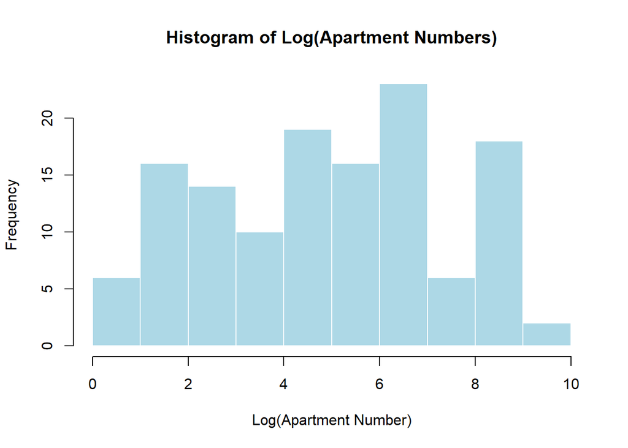

```r
apt_nums <- as.numeric(str_extract(au_data$address, "\\d+$"))
apt_nums <- apt_nums[!is.na(apt_nums)]

hist(log(apt_nums),
     main = "Histogram of Log(Apartment Numbers)",
     xlab = "Log(Apartment Number)",
     col = "lightblue",
     border = "white")
```

(f) The apartment numbers do not follow Benford’s Law.

The actual leading digit proportions deviate significantly from the theoretical probabilities; for instance, the digit “1” appears only 9.2% of the time (compared to the expected 30.1%), while “9” appears 14.6% of the time (rather than 4.6%). Thus, these numbers would not pass as authentic real-world data.

```r
leading_digits <- as.numeric(substr(as.character(apt_nums), 1, 1))
leading_digits <- leading_digits[leading_digits > 0]

actual_props <- prop.table(table(factor(leading_digits, levels = 1:9)))
benford_props <- log10(1 + 1/(1:9))

benford_check <- data.frame(
  Digit = 1:9,
  Actual_Proportion = as.numeric(actual_props),
  Benford_Proportion = benford_props
)
cat("\n3f. Benford's Law Comparison:\n")
```

```
3f. Benford's Law Comparison:
```

```r
print(benford_check)
```

```
  Digit Actual_Proportion Benford_Proportion
1     1        0.09230769         0.30103000
2     2        0.14615385         0.17609126
3     3        0.12307692         0.12493874
4     4        0.10000000         0.09691001
5     5        0.10769231         0.07918125
6     6        0.13846154         0.06694679
7     7        0.06153846         0.05799195
8     8        0.08461538         0.05115252
9     9        0.14615385         0.04575749
```